# Overview

We’re preparing our individual tree point clouds for segmentation by:

- Importing all point clouds into RiSCAN PRO with the correct CRS
- Generating crown‐hull shapefiles for each tree
- Configuring the shapefile in QGIS for manual segmentation

# Methods

## 1. Import Point Clouds into RiSCAN PRO

### 1.a Create a New Project

1. Open **RiSCAN PRO** and click **New Project**.

[figure not shown]

2. Save the project **locally** under a descriptive name.

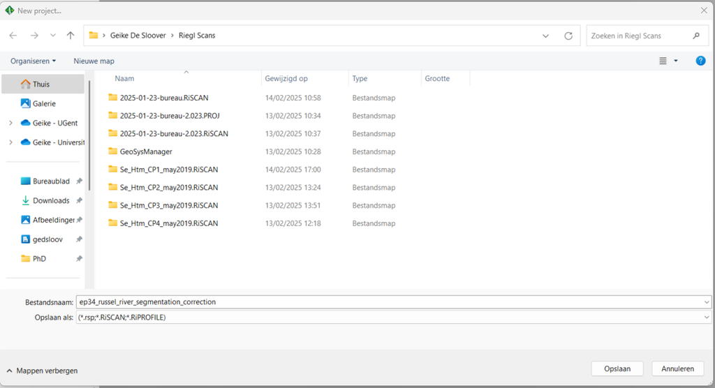

### 1.b Set the Coordinate Reference System

1. In the project manager, select your project name.
2. Navigate to **Edit → Attributes → Coordinate Reference Systems**.
3. In the GeoSysManager database, open **NQLD.gfx** and confirm. (You can find the NQLD.gfx file on the australia shares (called `qfl_australia_tls`), if you are working on a different region and using this manual as a guide, make a `.gfx` file for your own UTM Zone by following the steps [here](https://github.com/qforestlab/riscan_registration/blob/main/1.GeoSysManager.md).)

[figure not shown]

4. Apply these settings:

[figure not shown]

### 1.c Import the Point Clouds

1. Right‑click **Objects → Point Clouds** and choose **Import**.
2. Select all individual tree point clouds in the **selected_trees folder** and import them with the “Combine files” toggled off. Also import the **leftover** point cloud to be found in the Propagation folder with a name formatted like this: `2024-08-14_ep31_woopen_creek_ds1cm_20mbuffer_propagated.las`. And finally, import the trees that are outside the 40x90m AOI, to be found in the folder **trees_outside**, for these trees make sure to **toggle ON “Combine files”!** (The point clouds can be found on the qfl_australia_tls shares)

[figure not shown]

3. Set CRS to **WGS 84 / UTM zone 55 S** (or a different UTM zone, if not Australia), and **disable** “Combine files.”

[figure not shown]

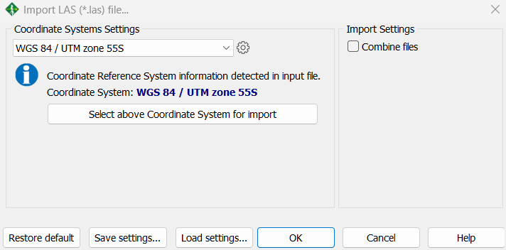

## > **Tip:** While the import runs (which can take several minutes), move on to step 2.

## Intermezzo - Quote of the Notebook

> *“What gets segmented, gets understood.”*  
> — TLS Rule #1

## 2. Generate Crown‐Hull Map of Individual Trees

### 2.a Create the Shapefile

1. Open `Get-shape-file-crowns.Rmd` (In this repo at [link](https://github.com/qforestlab/segmentation_correction/blob/main/get_crown_shape.Rmd) or on the qfl_australia_tls shares, under the folder “scripts”).
2. Update the folder paths to point at the individual‐tree point‐cloud directory (make sure the full plot point cloud is not in the same folder).
3. Run the RMarkdown in RStudio to produce a shapefile of each tree’s crown hull.

### 2.b Configure the Shapefile in QGIS

1. Open the new shapefile in **QGIS**.
2. Set the layer CRS to **WGS 84 / UTM zone 55 S** (or a different UTM zone, if not Australia).

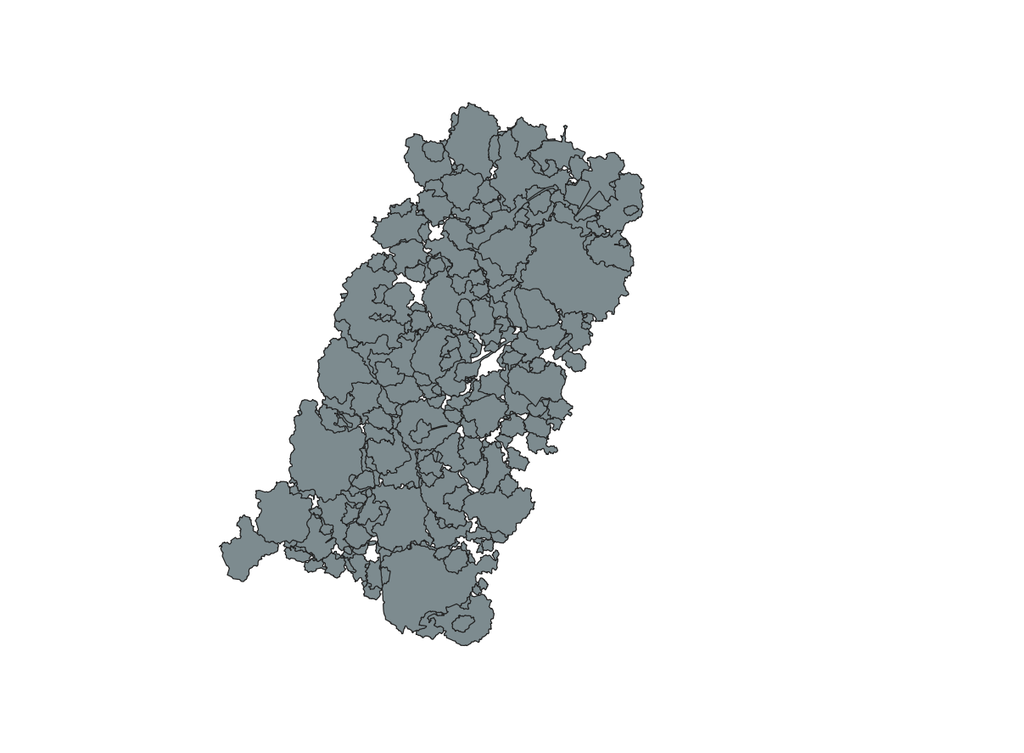

#### 2.b.i Add a “Segmented” Field

1. Open the **Attribute Table**, click **Edit** (pencil symbol), then **Add Field**.
2. Name the field `Segmented` and choose **Boolean**.

   Some versions of QGIS do not have the option Boolean (see screenshot). In that case, work with an integer and use 0 and 1 for false and true.

[figure not shown]

3. Also add a field `Notes` and choose **Text** as the type.
4. Save edits and exit editing mode by clicking the pencil symbol again.

[figure not shown]

[figure not shown]

#### 2.b.ii Style by Segmentation Status

1. In **Layer Properties → Symbology**, choose **Categorized** and select the `Segmented` field.
2. Click **Classify**, then assign **False/NULL** to red and **True** to green. Set opacity to 50%.

[figure not shown]

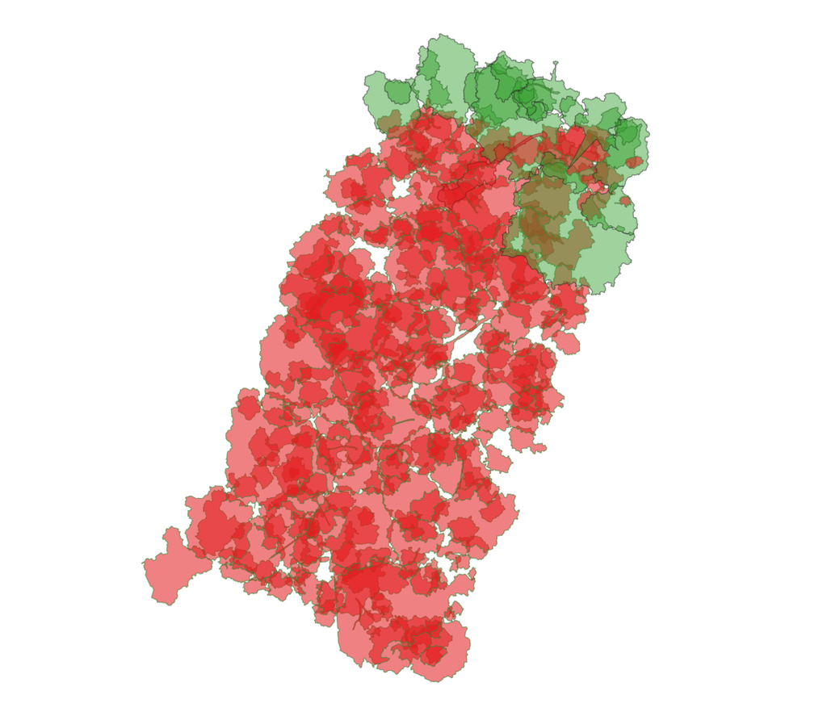

#### 2.b.iii Label Trees for Easy Identification

1. In **Layer Properties → Labels**, enable labeling by tree ID.
2. Adjust font size and placement so labels are legible.

[figure not shown]

You now have a clear top‐down view where each tree is color‑coded by segmentation status and with it’s name as label. As you segment a tree, toggle its `Segmented` attribute to **True** to update its color (make sure edit is toggled on as well).